# Team Lab 3

** Team Members: Andrew Maloney & Elain ob **

[**Link to Repository**](https://github.com/xazip/ds202_lab3)

## Reproducible Code and Analysis:

### Part one (cleaning)

##### 1. Before we could clean the data.frame, we had to understand it. Here is a general description of each variable in the data set.

```r
HAPPY <- readRDS("HAPPY.rds")
#head(HAPPY, 5)
# Info about  variables, gathered from the gssdata website.
# HAPPY - General happiness.   (All years available)
# YEAR - Gss year for this respondent.   (All years available)
# AGE - Age of the respondent. (All years available)
# SEX - Respondents sex (All years available)
# MARITAL - Marital status (All years available)
# DEGREE - Respondents highest degree   (All years available)
# FINRELA - Opinion of family income   (All years available)
# HEALTH - Condition of health   (Available 28 of 31 years recorded)
# WTSSALL - Weight of variables   (Available 17 of the 31 years recorded )
# PARTYID - Political party affiliation   (All years Available )
# POLVIEWS - Think of self as liberal or conservative   ( Available 29 of 31 years)
```

```r
str(HAPPY)
```

```
## 'data.frame':    62466 obs. of  11 variables:
##  $ HAPPY   : chr  "NOT TOO HAPPY" "NOT TOO HAPPY" "PRETTY HAPPY" "NOT TOO HAPPY" ...
##  $ YEAR    : int  1972 1972 1972 1972 1972 1972 1972 1972 1972 1972 ...
##  $ AGE     : chr  "23" "70" "48" "27" ...
##  $ SEX     : chr  "FEMALE" "MALE" "FEMALE" "FEMALE" ...
##  $ MARITAL : chr  "NEVER MARRIED" "MARRIED" "MARRIED" "MARRIED" ...
##  $ DEGREE  : chr  "BACHELOR" "LT HIGH SCHOOL" "HIGH SCHOOL" "BACHELOR" ...
##  $ FINRELA : chr  "AVERAGE" "ABOVE AVERAGE" "AVERAGE" "AVERAGE" ...
##  $ HEALTH  : chr  "GOOD" "FAIR" "EXCELLENT" "GOOD" ...
##  $ WTSSALL : num  0.445 0.889 0.889 0.889 0.889 ...
##  $ PARTYID : chr  "IND,NEAR DEM" "NOT STR DEMOCRAT" "INDEPENDENT" "NOT STR DEMOCRAT" ...
##  $ POLVIEWS: chr  "IAP" "IAP" "IAP" "IAP" ...
```

```r
dim(HAPPY)
```

```
## [1] 62466    11
```

```r
# HAPPY (Character)
# YEAR (Integer)
# AGE (Character) - seems a little weird
# SEX (Character)
# MARITAL (Character)
# DEGREE (Character)
# FINRELA (character)
# HEALTH (character)
# WTSSALL (numeric)
# PARTYID (character)
# POLVIEWS (Character)
```

##### Replace all indicated values by value NA.

```r
HAPPY[HAPPY == "DK"] <- NA
HAPPY[HAPPY == "IAP"] <- NA
HAPPY[HAPPY == "NA"] <- NA
```

##### 2. Cast Variables into the right Type

```r
library(dplyr)
HAPPY$AGE[HAPPY$AGE == "89 OR OLDER"] <- "89"
HAPPY <- HAPPY %>% mutate(HAPPY = factor(HAPPY), AGE = as.numeric(AGE), SEX = factor(SEX), MARITAL = factor(MARITAL), DEGREE = factor(DEGREE), FINRELA = factor(FINRELA), HEALTH = factor(HEALTH), PARTYID = factor(PARTYID), POLVIEWS = factor(POLVIEWS))
```

##### 3. Bring all levels of factors into a sensible order

```r
lvl_MARITAL_COL <- c("NEVER MARRIED", "SEPARATED", "MARRIED", "DIVORCED", "WIDOWED")
HAPPY <- HAPPY %>% mutate(MARITAL = factor(MARITAL, lvl_MARITAL_COL))

HAPPY_MEAN_AGE <- HAPPY %>% group_by(MARITAL) %>% summarize(n = n(), mean_age = mean(AGE, na.rm = TRUE)) %>% arrange((mean_age))
levels(HAPPY$MARITAL)
```

```
## [1] "NEVER MARRIED" "SEPARATED"     "MARRIED"       "DIVORCED"
## [5] "WIDOWED"
```

```r
HAPPY_MEAN_AGE
```

```
## # A tibble: 6 x 3
##   MARITAL           n mean_age
##   <fct>         <int>    <dbl>
## 1 NEVER MARRIED 13167     32.6
## 2 SEPARATED      2167     43.5
## 3 MARRIED       33131     46.6
## 4 DIVORCED       7976     48.3
## 5 <NA>             25     52.9
## 6 WIDOWED        6000     70.1
```

```r
lvl_HAPPY_COL <- c("NOT TOO HAPPY", "PRETTY HAPPY", "VERY HAPPY")
HAPPY <- HAPPY %>% mutate(HAPPY = factor(HAPPY, lvl_HAPPY_COL))
levels(HAPPY$HAPPY)
```

```
## [1] "NOT TOO HAPPY" "PRETTY HAPPY"  "VERY HAPPY"
```

```r
lvl_DEGREE_COL <- c("LT HIGH SCHOOL", "HIGH SCHOOL", "JUNIOR COLLEGE", "BACHELOR", "GRADUATE")
HAPPY <- HAPPY %>% mutate(DEGREE = factor(DEGREE, lvl_DEGREE_COL))
levels(HAPPY$DEGREE)
```

```
## [1] "LT HIGH SCHOOL" "HIGH SCHOOL"    "JUNIOR COLLEGE" "BACHELOR"
## [5] "GRADUATE"
```

```r
lvl_HEALTH_COL <- c("POOR", "FAIR", "GOOD", "EXCELLENT")
HAPPY <- HAPPY %>% mutate(HEALTH = factor(HEALTH, lvl_HEALTH_COL))
levels(HAPPY$HEALTH)
```

```
## [1] "POOR"      "FAIR"      "GOOD"      "EXCELLENT"
```

```r
lvl_FINRELA_COL <- c("FAR BELOW AVERAGE", "BELOW AVERAGE", "AVERAGE", "ABOVE AVERAGE", "FAR ABOVE AVERAGE")
HAPPY <- HAPPY %>% mutate(FINRELA = factor(FINRELA, lvl_FINRELA_COL))
levels(HAPPY$FINRELA)
```

```
## [1] "FAR BELOW AVERAGE" "BELOW AVERAGE"     "AVERAGE"
## [4] "ABOVE AVERAGE"     "FAR ABOVE AVERAGE"
```

```r
lvl_PARTYID_COL <- unique(c("STRONG REPUBLICAN", "NOT STR REPUBLICAN" ,"IND,NEAR REP", "INDEPENDENT", "IND,NEAR DEM", "NOT STR DEMOCRAT", "STRONG DEMOCRAT", "OTHER"))
HAPPY <- HAPPY %>% mutate(PARTYID = factor(PARTYID, lvl_PARTYID_COL))
levels(HAPPY$PARTYID)
```

```
## [1] "STRONG REPUBLICAN"  "NOT STR REPUBLICAN" "IND,NEAR REP"
## [4] "INDEPENDENT"        "IND,NEAR DEM"       "NOT STR DEMOCRAT"
## [7] "STRONG DEMOCRAT"    "OTHER"
```

```r
lvl_POLVIEWS_COL <- c("EXTRMLY CONSERVATIVE", "CONSERVATIVE", "SLGHTLY CONSERVATIVE", "MODERATE", "SLIGHTLY LIBERAL", "LIBERAL", "EXTREMELY LIBERAL")
HAPPY <- HAPPY %>% mutate(POLVIEWS = factor(POLVIEWS, lvl_POLVIEWS_COL))
levels(HAPPY$POLVIEWS)
```

```
## [1] "EXTRMLY CONSERVATIVE" "CONSERVATIVE"         "SLGHTLY CONSERVATIVE"
## [4] "MODERATE"             "SLIGHTLY LIBERAL"     "LIBERAL"
## [7] "EXTREMELY LIBERAL"
```

### Part 2 (exploration)

##### 1. Investigate the distributions of 2 different variables

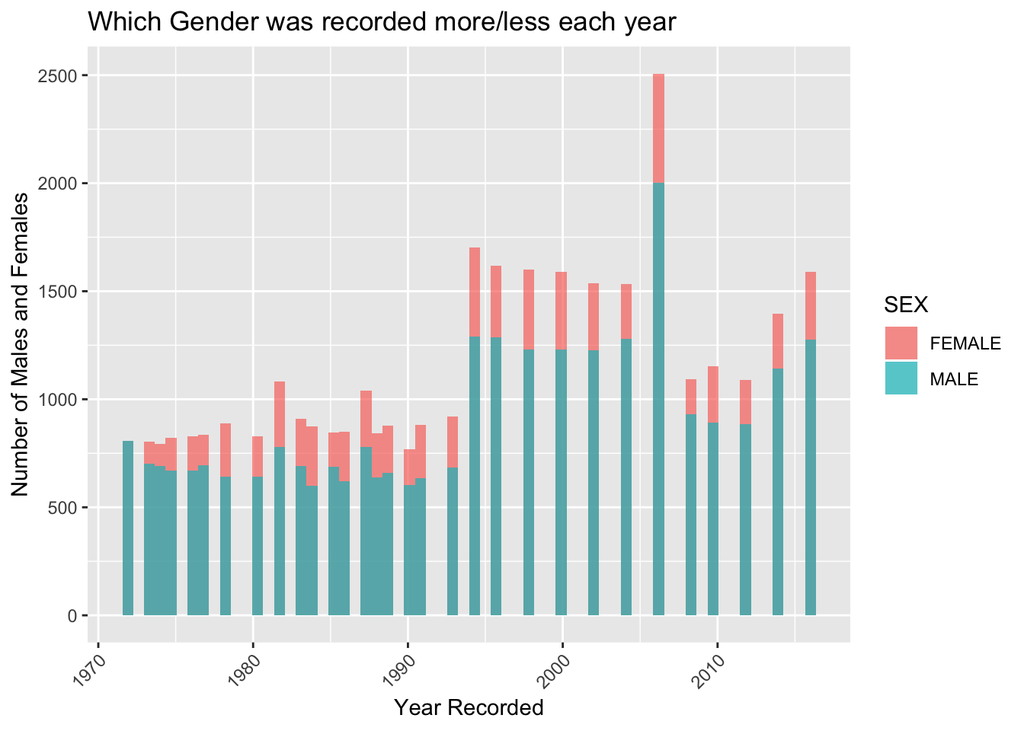

```r
library(ggplot2)

ggplot(HAPPY, aes(x = YEAR, fill = SEX)) +
  geom_histogram(binwidth = .7, alpha = .7 , position = "identity", na.rm = TRUE)+
  ggtitle("Which Gender was recorded more/less each year") + xlab("Year Recorded") + ylab("Number of Males and Females") + theme(axis.text.x = element_text(angle = 45, vjust = 1, hjust = 1))
```

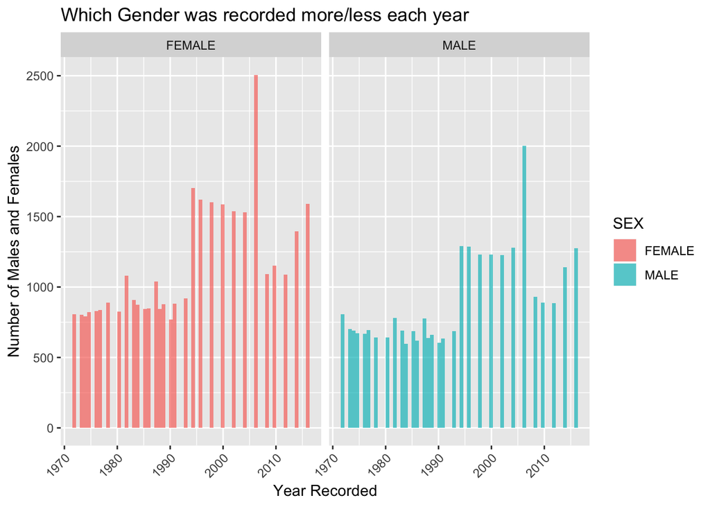

```r
ggplot(HAPPY, aes(x = YEAR, fill = SEX)) +
  geom_histogram(binwidth = .7, alpha = .7 , position = "identity", na.rm = TRUE) +
  facet_grid(.~SEX)+
  ggtitle("Which Gender was recorded more/less each year") + xlab("Year Recorded") + ylab("Number of Males and Females") + theme(axis.text.x = element_text(angle = 45, vjust = 1, hjust = 1))
```

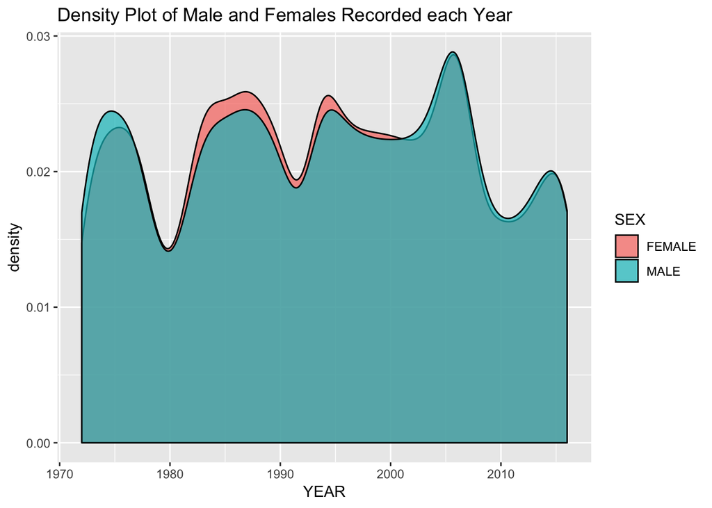

```r
ggplot(HAPPY, aes(x = YEAR, fill = SEX))+
  geom_density(alpha = .7, na.rm = TRUE) +
  ggtitle("Density Plot of Male and Females Recorded each Year ")
```

###### Looking at the graphs, we see the sample size is around 62466, the year the person was recorded was plotted on the x-axis and the number of males and females was plotted on the y-axis. There were more females recorded than males almost every year. The histogram is multimodal, skewed to the left, and has no apparent outliers; this makes sense due to the large sample size and the long time span from which the observations were taken.

##### 2. Investigate the relationship between happiness and three other variables in the data

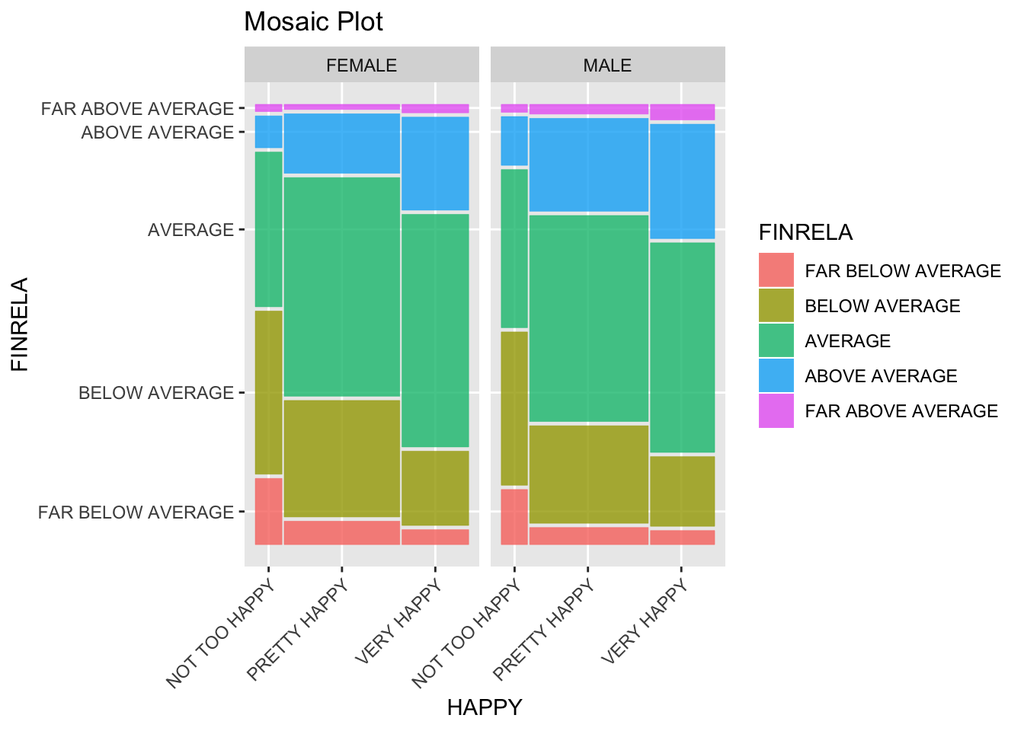

```r
library(ggmosaic)
ggplot(HAPPY)+
  geom_mosaic(aes(x = product(HAPPY), fill = FINRELA), na.rm = TRUE)+
  facet_grid(.~SEX) +
  ggtitle("Mosaic Plot") + xlab("Happy Level") +ylab("FINRELA(Income)") + theme(axis.text.x = element_text(angle = 45, vjust = 1, hjust = 1))
```

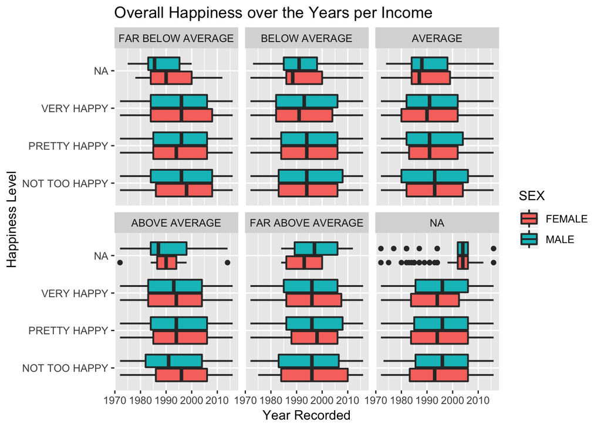

```r
ggplot(HAPPY, aes(x = HAPPY, y = YEAR, fill = SEX))+
  geom_boxplot(size = 0.7, na.rm = TRUE)+ facet_wrap(~FINRELA)+ coord_flip()+
  ggtitle("Overall Happiness over the Years per Income ") + xlab("Happiness Level") + ylab("Year Recorded")
```

##### 3. What do you learn from the data set?

###### This dataset was pretty hard to work with. Maybe because this was our first time cleaning in r. It also took us awhile to understand what “leveling factors” really was about. We found we could get the most logical results when working variables HAPPY, YEAR, AGE, SEX, HEALTH, FINRELA. Working with other factor variables, we couldn’t get the best looking results based on the graphs. We learned how to clean our first data.frame with this lab assignment. This was also a good learning lesson working with the dplyr, tidyverse, fct, and ggplot packages.

###### Overall, think the most important thing we learned when working with the HAPPY data set is how important it is to work around errors and not get stuck but also remember that cleaning should take up 80% of the time.